# Centroidal Voronoi Tessellations

In this tutorial, we demonstrate how we can compute centroidal Voronoi tessellations. These are tessellations for which each generator is approximately the centroid of its associated polygon, except for boundary generators which are fixed in place. This method is only applicable to clipped tessellations.

We give a simple example. First, we compute the clipped tessellation of a point set.

```julia
using DelaunayTriangulation
using CairoMakie
using StableRNGs
rng = StableRNG(123)
points = 25randn(rng, 2, 500)
tri = triangulate(points; rng)
vorn = voronoi(tri, clip=true)
```

```
Voronoi Tessellation.
    Number of generators: 500
    Number of polygon vertices: 1032
    Number of polygons: 500
```

To now compute the centroidal tessellation, use `centroidal_smooth`. ( If you want to straight from a triangulation to a centroidal tessellation, you can also just use `smooth_vorn = voronoi(tri, clip = true, smooth = true)`.)

```julia
smooth_vorn = centroidal_smooth(vorn; rng)
```

```
Voronoi Tessellation.
    Number of generators: 500
    Number of polygon vertices: 1074
    Number of polygons: 500
```

Let us now compare the two tessellations.

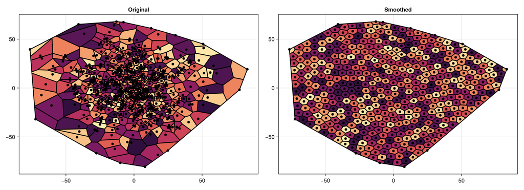

```julia
fig = Figure()
ax1 = Axis(fig[1, 1], title="Original", width=600, height=400)
ax2 = Axis(fig[1, 2], title="Smoothed", width=600, height=400)
voronoiplot!(ax1, vorn, colormap=:matter, strokewidth=2)
voronoiplot!(ax2, smooth_vorn, colormap=:matter, strokewidth=2)
resize_to_layout!(fig)
fig
```

As you can see, the tiles are all reasonably uniform, and their generators do look to be near the centroid of their corresponding tile. Note that this function `centroidal_smooth` is iterative, and you can control the iteration limits and the tolerance of the iterations (based on the maximum displacement of any generator at each iteration) using the `maxiters` and `tol` keyword arguments.

## Just the code

An uncommented version of this example is given below. You can view the source code for this file [here](https://github.com/JuliaGeometry/DelaunayTriangulation.jl/tree/main/docs/src/literate_tutorials/centroidal.jl).

```julia
using DelaunayTriangulation
using CairoMakie
using StableRNGs
rng = StableRNG(123)
points = 25randn(rng, 2, 500)
tri = triangulate(points; rng)
vorn = voronoi(tri, clip=true)

smooth_vorn = centroidal_smooth(vorn; rng)

fig = Figure()
ax1 = Axis(fig[1, 1], title="Original", width=600, height=400)
ax2 = Axis(fig[1, 2], title="Smoothed", width=600, height=400)
voronoiplot!(ax1, vorn, colormap=:matter, strokewidth=2)
voronoiplot!(ax2, smooth_vorn, colormap=:matter, strokewidth=2)
resize_to_layout!(fig)
fig
```

*This page was generated using Literate.jl.*